# **Neural Networks Project Solution**

**MODEL 6 - SGD with learning rate 0.1**

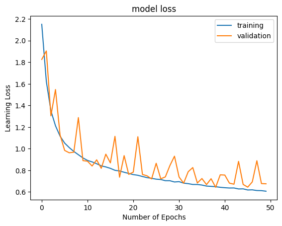

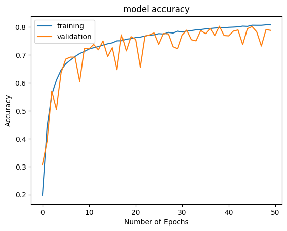

```
Classification Report
--------------------------------------
              precision    recall  f1-score   support

           0       0.86      0.79      0.83      1814
           1       0.77      0.82      0.79      1828
           2       0.81      0.75      0.78      1803
           3       0.73      0.69      0.71      1719
           4       0.80      0.85      0.83      1812
           5       0.63      0.84      0.72      1768
           6       0.83      0.72      0.77      1832
           7       0.85      0.75      0.80      1808
           8       0.64      0.78      0.70      1812
           9       0.85      0.66      0.74      1804

    accuracy                           0.77     18000
   macro avg       0.78      0.77      0.77     18000
weighted avg       0.78      0.77      0.77     18000



Confusion Matrix
--------------------------------------
```

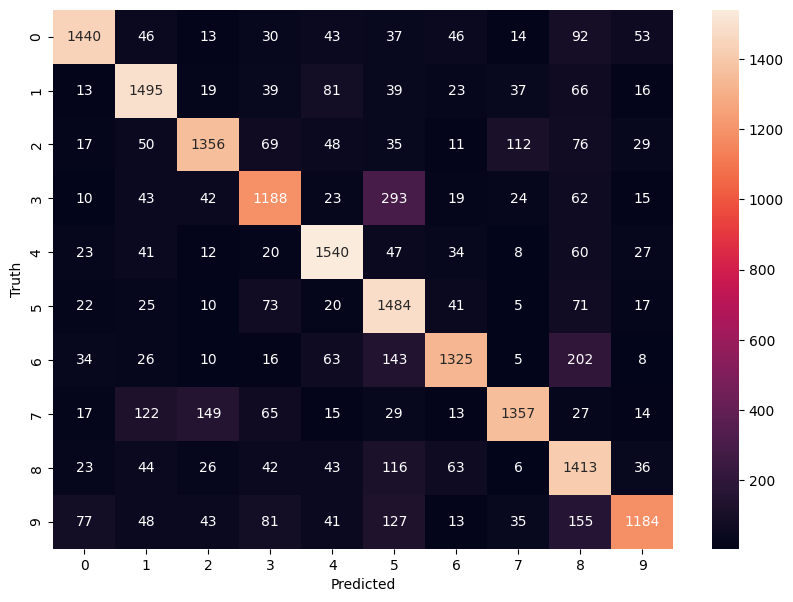

```python
# create model
hf_model_6 = Sequential()
hf_model_6.add(Dense(128 , activation='relu', input_shape = (1024, )))
hf_model_6.add(Dense(64, activation='relu'))
hf_model_6.add(Dense(10, activation = 'softmax'))

# Compile the model
sgd = optimizers.SGD(lr = 0.1)
hf_model_6.compile(optimizer = sgd, loss=losses.categorical_crossentropy, metrics=['accuracy'])

history = hf_model_6.fit(X_train, y_train_cat, validation_data=(X_valid, y_valid_cat), epochs=50, batch_size=32, verbose=0)

print_hf_report(history, hf_model_6)
```

**Observations:**

- Accuracy dropped to 77% with lr 0.1.
- Lot of noise in validation data.
- Lets go ahead with Model 5. Change the optimizer to Adam and see the difference.

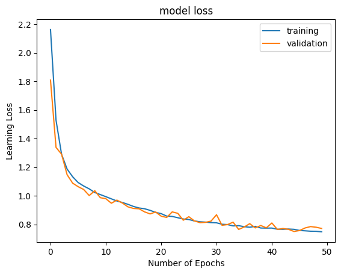

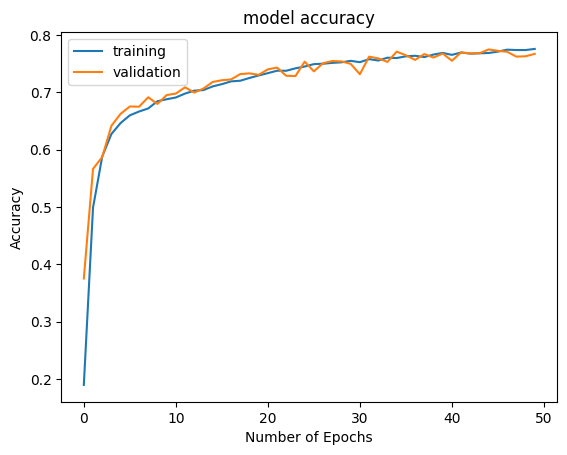

```
Classification Report
--------------------------------------
              precision    recall  f1-score   support

           0       0.76      0.80      0.78      1814
           1       0.79      0.79      0.79      1828
           2       0.84      0.77      0.81      1803
           3       0.73      0.68      0.70      1719
           4       0.78      0.81      0.80      1812
           5       0.69      0.73      0.71      1768
           6       0.76      0.73      0.75      1832
           7       0.84      0.81      0.82      1808
           8       0.68      0.72      0.70      1812
           9       0.74      0.75      0.74      1804

    accuracy                           0.76     18000
   macro avg       0.76      0.76      0.76     18000
weighted avg       0.76      0.76      0.76     18000



Confusion Matrix
--------------------------------------
```

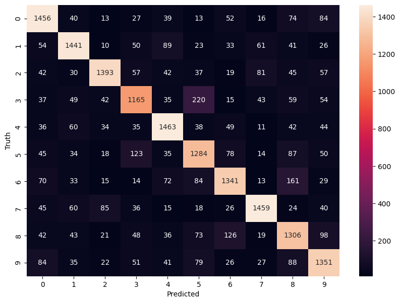

```python
# create model
hf_model_7 = Sequential()
hf_model_7.add(Dense(128 , activation='relu', input_shape = (1024, )))
hf_model_7.add(Dense(64, activation='relu'))
hf_model_7.add(Dense(10, activation = 'softmax'))

# Compile the model
adam = optimizers.Adam(lr = 0.001)
hf_model_7.compile(optimizer = adam, loss=losses.categorical_crossentropy, metrics=['accuracy'])

history = hf_model_7.fit(X_train, y_train_cat, validation_data=(X_valid, y_valid_cat), epochs=50, batch_size=64, verbose=0)

print_hf_report(history, hf_model_7)
```

**Observations:**

- With Adam optimizer using LR 0.001, the performance of the model is similar to that of SGD. However, accuracy dropped to 76%.
- Among all the above models, Model 5 seem to fair better with 80% accuracy than all.
- Adding of Batch Normalization and Dropout also were of not much use.
- Lets consider simple Model 5 as the final model with SGD optimizer LR 0.01.

```python
# predicting the model on test data
y_pred = hf_model_5.predict(X_test)

y_pred_final=[]
for i in y_pred:
  y_pred_final.append(np.argmax(i))

index = 0
misclassified_images = []
for label, predict in zip(y_test, y_pred_final):
    if label != predict:
        misclassified_images.append(index)
    index +=1
print(misclassified_images)
print(len(misclassified_images))
```

[output not shown]

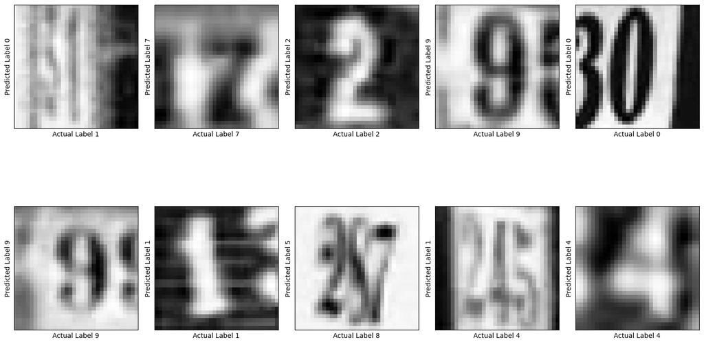

```python
n = 1
plt.figure(figsize=(15,10))

for i in range(10):
  plt.subplot(2, 5, n)
  n = n+1
  plt.imshow(X_test[i].reshape(32, 32),cmap='Greys')
  pred = hf_model_5.predict(X_test[i].reshape(-1, 1024))
  plt.xlabel('Actual Label %d'% y_test[i], fontsize=10)
  plt.ylabel('Predicted Label %d'% pred.argmax(), fontsize=10)
  plt.xticks([], [])
  plt.yticks([], [])

plt.tight_layout()
```